# Prisfastsættelse & OAS

Når betalingsrækken selv afhænger af renten

Niklas Lehmann Jensen

#### Fra konverteringsmotor til markedspris

[figure not shown]

#### Dagens spørgsmål

- Hvordan prissætter vi en obligation, når **cash flowet selv afhænger af renten**?
- Hvorfor rammer renten prisen gennem **to kanaler**?
- Hvad er **OAS**, og hvorfor er det ikke **LYS** eller bidrag?
- Hvordan findes OAS ved at få **modelpris = markedskurs**?

## Prisfastsættelsesmotoren

#### En konverterbar obligation er mange mulige betalingsrækker

$$P_{\text{model}}(OAS)=\sum_m \pi_m\sum_{t=1}^{T}DF_t^{(m)}(OAS)\,CF_t^{(m)}$$

- Rentesti $m$ skaber sin egen række $CF_1^{(m)},\ldots,CF_T^{(m)}$
- $CF_t^{(m)}$ afhænger af $Gain_t$, $CPR_t$, $UDT_t$ og $Burnout_t$
- Stisum og baglæns rekursion er to numeriske billeder af **samme nutidsværdi**

#### Renten rammer prisen gennem to kanaler

[figure not shown]

#### Værdien afhænger af hele modeltilstanden

| Instrument | Værdien afhænger af | Notation |
| --- | --- | --- |
| Inkonverterbar | tid og rente | $V(t,r_t)$ |
| Konverterbar, én gruppe | + låntagerpulje | $V(t,r_t,Burnout_t)$ |
| Konverterbar, mikstur | + gruppevægte | $V(t,r_t,Burnout_t,w_{1,t},\ldots,w_{J,t})$ |

**Indsigt**

Renten fortæller, **hvordan** vi diskonterer. Tilstanden fortæller, **hvilke cash flows** vi diskonterer.

## Låntagers option

#### Investor er kort låntagers call-option

- Låntager kan indfri til **kurs 100** på bestemte terminer
- Ved rentefald stiger $Gain_t$ og typisk $CPR_t$
- Investor mister en attraktiv kupon og må geninvestere til lavere rente

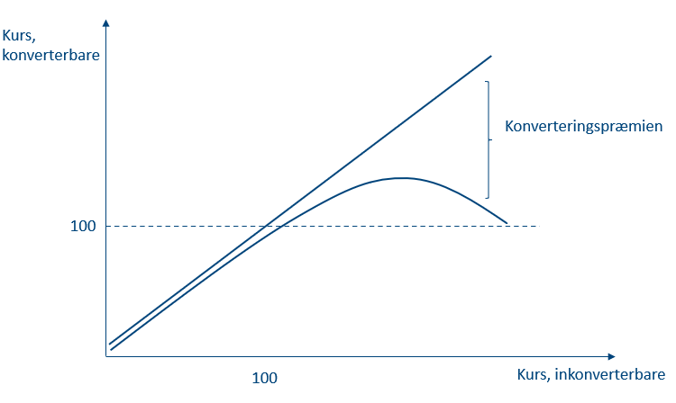

#### Optionsværdien er stor for høje kuponer

$$V_{\text{call}}=P_{\text{inkonv}}-P_{\text{konv}}$$

| Obligation | $P_{\text{konv}}$ | $P_{\text{inkonv}}$ | $V_{\text{call}}$ | Relativ værdi |
| --- | --- | --- | --- | --- |
| 6% NYK E SDO 2053 | 103,07 | 145,35 | 42,28 | 41,0% |
| 5% NYK E SDO 2053 | 102,09 | 131,74 | 29,65 | 29,0% |
| 1% NYK E SDO 2053 | 79,91 | 85,25 | 5,34 | 6,7% |

#### Optionens værdi er ikke en lille teknisk korrektion

**Indsigt**

For høje kuponer kan forskellen mellem den inkonverterbare og konverterbare værdi være **omkring 30–40 kurspoint**.

- Modellen skal derfor værdiansætte en betalingsrække, som låntager kan ændre, når renten bevæger sig.

#### En knude samler betaling og fortsættelsesværdi

- $V_t\approx\dfrac{1}{1+r_t\Delta t}\sum_{s\in\{u,mid,d\}}\pi_s(CF_s+V_s)$

[figure not shown]

#### Når renten ikke er nok, må knuden kende tilstanden

**Definition**

En nodeværdi er $V(t,r,S_t)$: samme rente kan give forskellig værdi, hvis **burnout, gruppevægte eller valgt strategi** er forskellige.

- Tilstanden bevæger sig **fremad**: rente → $Gain$ → $CPR$ → ny pulje
- Værdien beregnes **baglæns**: betaling + fortsættelsesværdi → nutidsværdi
- Interpolation forbinder den beregnede tilstand med de lagrede nodeværdier

#### Prisrelationen gør optionen synlig

$$P_{\text{konv}}=P_{\text{inkonv}}-V_{\text{call}}$$

| 5% NYK 2053 · 11. oktober 2024 | Kurspoint |
| --- | --- |
| Konverterbar pris inkl. vedhængende rente | 102,09 |
| Inkonverterbar betalingsrække | 131,01 |
| **Optionsværdi** | **28,92** |

## Tre kurver — tre roller

#### Prisningskurve, refinansieringskurve og OAS-kurve må ikke blandes

| Kurve | Notation | Brug |
| --- | --- | --- |
| Prisningskurve | $z^{\text{swap}}_{\tau}$ | reference til model og diskontering |
| Refinansieringskurve | $z^{\text{refi}}_{\tau}=z^{\text{swap}}_{\tau}+LYS_{\tau}$ | låntagers alternative finansiering |
| OAS-justeret kurve | $z^{\text{swap}}_{\tau}+OAS$ | kalibrerer modelpris til markedskurs |

#### LYS former låntagers alternativ

$$z^{\text{refi}}_{\tau}=z^{\text{swap}}_{\tau}+LYS_{\tau}$$

$$LYS_{\tau}\uparrow\ \Rightarrow\ Gain_t\downarrow\ \Rightarrow\ CPR_t\downarrow$$

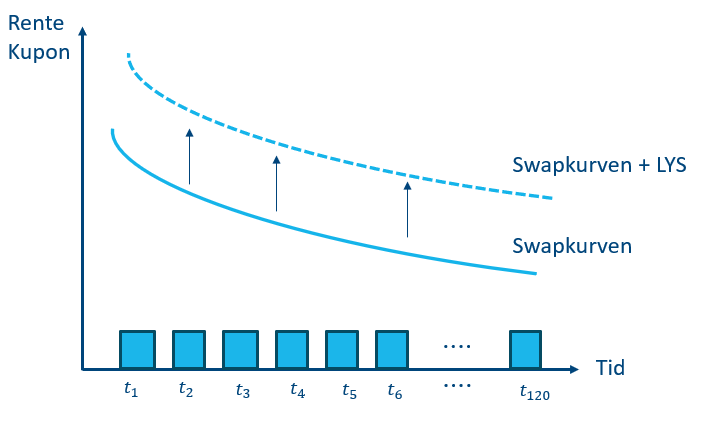

#### LYS og OAS er forskellige objekter på hver sin side

**Definition**

**LYS:** spread på låntagers refinansieringskurve → $Gain_t$ → $CPR_t$ → cash flows.

**OAS:** spread på investors diskonteringskurve → $DF_t$ → $P_{\text{model}}$; justeres til markedskursen.

- **Bidrag** er instituttets kontraktuelle betaling fra låntager — ikke LYS og ikke OAS.

## OAS og kalibrering

#### OAS lukker gabet mellem model og marked

$$P_{\text{model}}(OAS)=P_{\text{market}}$$

$$DF_t(OAS)=\frac{1}{(1+z_t^{\text{swap}}+OAS)^t}$$

- $OAS\uparrow\Rightarrow DF_t\downarrow\Rightarrow P_{\text{model}}\downarrow$

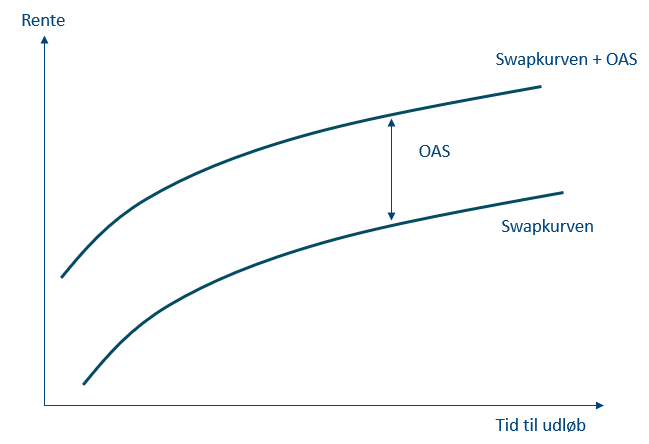

#### OAS er også et modelafhængigt residual

**Fortolkningsværn**

OAS er ikke direkte observerbart og er ikke et rent mål for kreditrisiko.

- Afhænger af rentemodel, prepaymentmodel og referencekurve
- Kan opsamle **modelfejl**, likviditet, volatilitet samt udbud/efterspørgsel
- Et negativt OAS betyder en høj markedskurs relativt til modellen ved $OAS=0$

#### OAS-indekset viser skiftende markedsregimer

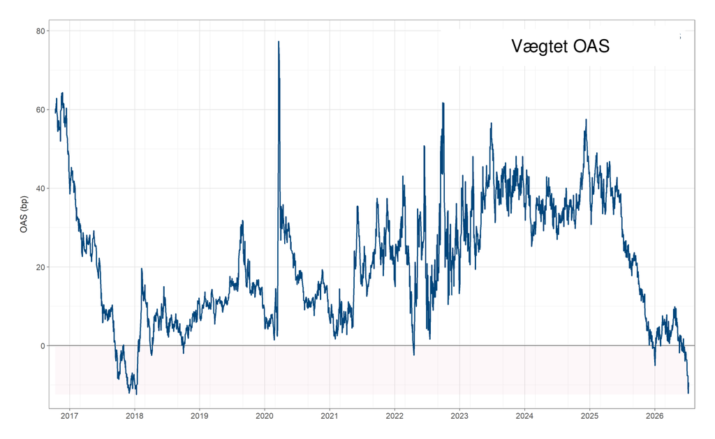

#### OAS findes ved at køre modellen igen

**Fremgangsmåde**

1. Generér cash flows på mulige rentestier.
2. Vælg referencekurven $z^{\text{swap}}_{\tau}$.
3. Læg et foreløbigt OAS til diskonteringen.
4. Justér OAS, indtil $P_{\text{model}}(OAS)=P_{\text{market}}$.
5. Brug den kalibrerede motor til risikomål.

#### Nøgletal er genkørsler af den samme motor

| Stød | Hvad ændres? | Hvad genberegnes? |
| --- | --- | --- |
| Rente | prisningskurven | diskontering **og** CPR |
| CPR | prepaymentantagelsen | cash flows direkte |
| LYS | refinansieringskurven | $Gain_t$ og CPR |
| OAS | diskonteringsspændet | modelpris / spread-risk |

**Indsigt**

Samme motor. Fire kontrollerede spørgsmål. Det er næste forelæsning.

## Appendiks — selvstudium

#### A1 · Et lille værdigitter med delvis konvertering

| Gren | Vægt | CPR | Betaling | Værdi efter betaling |
| --- | --- | --- | --- | --- |
| Op | 25% | 0% | 3 | 96 |
| Midt | 50% | 0% | 3 | 100 |
| Ned | 25% | 40% | 43 | 63,6 |

$$V_t^{\text{konv}}=100{,}88,\qquad V_t^{\text{inkonv}}=101{,}47,\qquad V_{\text{call}}=0{,}59$$

#### A2 · Interpolation forbinder tilstand og nodeværdi

[figure not shown]

#### A3 · Positiv Gain er ikke altid “konvertér nu”

[figure not shown]

#### A4 · Samme obligation, to konsistente opgørelser

| 5% NYK 2053 | Opgørelse A | Opgørelse B |
| --- | --- | --- |
| Konverterbar pris | 102,09 | 102,09 |
| Inkonverterbar værdi | 131,01 | 131,74 |
| Optionsværdi | 28,92 | 29,65 |
| Relativ optionsværdi | — | 29,0% |

- Forskellen skyldes modelkørsel og opgørelse af bl.a. vedhængende rente — bland ikke kolonnerne.

#### A5 · Data til selvstudie: 6% RD og 1% RD

| Størrelse | 6% RD 2053 | 1% RD 2050 |
| --- | --- | --- |
| Kurs | 103,067 | 77,410 |
| Inkonverterbar værdi | 132,448 | 81,866 |
| Kronekonveksitet | −0,3329 | 0,436 |
| $P_0(+\Delta y)$ | 103,098 | 76,144 |
| $P_0(-\Delta y)$ | 103,028 | 78,687 |
| $\Delta y$ | 0,0015 | 0,0015 |